# RMarkdown Exercise #1 - Answer Key

Rob Cavanaugh

2022-08-02

## About this document

The goal of this exercise is to provide an opportunity to generate a reproducible report, applying skills learned in this workshop to date.

- Using basic rmarkdown formatting
- Using inline code to report basic demographic information
- Previewing, Cleaning, and Organizing data
- Reproducing Figure 1A from Giovannone & Theodore, 2022 (https://osf.io/dhybk/)

## About Giovannone & Theodore 2022

**Title:** Do individual differences in lexical reliance reflect states or traits? Giovannone & Theodore, 2022 (pre-print)

**Abstract:** Research suggests that individuals differ in their reliance on lexical information for speech perception. However, the locus of these differences is not yet known; nor is it known whether these individual differences reflect a context-dependent “state” or a stable listener “trait.” Here we test the hypothesis that individual differences in lexical reliance are a stable trait that is linked to individuals’ relative weighting of lexical and acoustic-phonetic information for speech perception. Listeners (n = 73) completed three measures of lexical processing at each of two sessions. Robust lexical effects on speech perception were observed for each task in the aggregate. For all three measures, individual differences in lexical reliance were stable across sessions, suggesting that performance in these tasks may reflect stable traits. However, relationships among the three tasks in each session were weak, indicative of low convergent validity across tasks. For two of the three tasks, increased reliance on lexical information was associated with weaker reliance on acoustic-phonetic information. Collectively, these results (1) suggest that individual differences in lexical reliance are stable traits that reflect relative weighting of acoustic-phonetic and lexical cues for speech perception, and (2) highlight the need for a better understanding of the psychometric characteristics of tasks used in the psycholinguistic domain to build theories that can accommodate individual differences in mapping speech to meaning.

Figure 1. Panel A:

**Change the following code chunk so that it only displays the image and not the code**

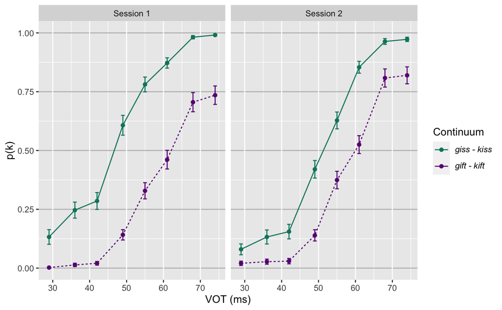

## Load packages

```r
library(tidyverse)
library(here)
```

## Read in data

```r
demographics = read.csv(here("04-rmarkdown", "giovannone2022", "TIMETIME-Demographics.csv"), stringsAsFactors = TRUE)
ganong = read.csv(here("04-rmarkdown", "giovannone2022", "TIMETIME-Ganong.csv"), stringsAsFactors = TRUE)
```

## Demographics paragraph

Our first task is to replicate this paragraph from the manuscript using inline R code:

> Participants (n = 142) were recruited from the Prolific participant pool(https://www.prolific.co;Palan & Schitter, 2018). All participants were monolingual English speakers born in and currently residing in theUnited States with no previous history of language-related disorders. Twenty-two participants were excluded due to failure to comply with task instructions as described in the procedure section below. The final sample included 120 participants at session one and 73 participants who also completed session two. Given that testing the primary hypotheses requires examining performance across the two sessions, the analyses presented here consider the participants (n = 73) who completed both sessions.

> With respect to demographic characteristics,the sample included 50 women, 21 men, and 2 individuals who preferred not to report gender. All participants were between 18 –35 years of age (mean = 26 years, SD = 5 years).Invitations to complete session twowere issued two weeks after the completion of session one. The mean time between sessions was 17 days (SD = 4 days; range = 14 – 35 days)

So we need the following:

- total number of people
- number of people completing both sessions
- gender
- sex
- age (mean, sd, min, max)
- days between sessions (mean, sd, min, max)

### Preview the demographics dataframe

```r
head(demographics)
```

```
##             ID Age    Sex Group N.Sessions Days Headphone
## 1 TIMETIME.001  29 Female     4          2   20      Pass
## 2 TIMETIME.002  29 Female     2          2   14      Pass
## 3 TIMETIME.003  28 Female     1          2   25      Pass
## 4 TIMETIME.004  33 Female     1          1   NA      Pass
## 5 TIMETIME.005  35   Male     1          1   NA      Pass
## 6 TIMETIME.006  33   Male     1          2   14      Pass
```

```r
# how many people completed each sessions
both_sessions = demographics %>%
  # for each possible value of N.Sessions, how many are there?
  count(N.Sessions)

both_sessions
```

```
##   N.Sessions  n
## 1          1 47
## 2          2 73
```

```r
# How many people reported as male, female, or prefer not to say
gender = demographics %>%
  # only individuals who completed both sessions
  filter(N.Sessions == 2) %>%
  # get distinct rows for ID and sex
  distinct(ID, Sex) %>%
  # how many of each are in the column Sex
  count(Sex)

gender
```

```
##                 Sex  n
## 1            Female 50
## 2              Male 21
## 3 Prefer not to say  2
```

```r
age = demographics %>%
  # only individuals who completed both sessions
  filter(N.Sessions == 2) %>%
  # calculate summary statistics for age
  # note the rounding of mean and sd
  summarise(Mean = round(mean(Age), digits=0), # 26 years.
            SD = round(sd(Age), digits=0), # 5 years.
            Min = min(Age), # 18 - 35 years.
            Max = max(Age))

age
```

```
##   Mean SD Min Max
## 1   26  5  18  35
```

```r
time_between_sessions = demographics %>%
  # only individuals who completed both sessions
  filter(N.Sessions == 2) %>%
  # How many days inbetween - mean, sd, min, max
  summarise(Mean = round(mean(Days), digits=0),
            SD = round(sd(Days), digits=0),
            Min = min(Days),
            Max = max(Days))

time_between_sessions
```

```
##   Mean SD Min Max
## 1   17  4  14  35
```

Paragraph 1:

Paragraph 2:

With respect to demographic characteristics,the sample included 50 women, 21 men, and 2 individuals who preferred not to report gender. All participants were between 18-35 years of age (mean= 26 years, SD= 5 years).Invitations to complete session twowere issued two weeks after the completion of session one. The mean time between sessions was 17 days (SD = 4 days; range= 14 – 35 days)

## Recreating the figure

Preview the ganong data. This time, lets use a the `paged_table()` function from Rmarkdown. This only works with HTML output, but allows the reader to tab through the table

```r
rmarkdown::paged_table(ganong)
```

| ID | Task | Session | N.Sessions | Trial | Stimulus | Continuum | Step | VOT | Response |
| --- | --- | --- | --- | --- | --- | --- | --- | --- | --- |
| TIMETIME.001 | Ganong | 1 | 2 | 1 | gift_06 | gift | 6 | 42 | 0 |
| TIMETIME.001 | Ganong | 1 | 2 | 2 | gift_08 | gift | 8 | 55 | 0 |
| TIMETIME.001 | Ganong | 1 | 2 | 3 | giss_10 | giss | 10 | 68 | 1 |
| TIMETIME.001 | Ganong | 1 | 2 | 4 | giss_11 | giss | 11 | 74 | 1 |
| TIMETIME.001 | Ganong | 1 | 2 | 5 | gift_05 | gift | 5 | 36 | 0 |
| TIMETIME.001 | Ganong | 1 | 2 | 6 | giss_08 | giss | 8 | 55 | 1 |
| TIMETIME.001 | Ganong | 1 | 2 | 7 | giss_04 | giss | 4 | 29 | 0 |
| TIMETIME.001 | Ganong | 1 | 2 | 8 | giss_06 | giss | 6 | 42 | 0 |
| TIMETIME.001 | Ganong | 1 | 2 | 9 | gift_10 | gift | 10 | 68 | 1 |
| TIMETIME.001 | Ganong | 1 | 2 | 10 | gift_09 | gift | 9 | 61 | 0 |

[output cut: 9990 more lines]

Calculate summary statistics for each variable

```r
summary(ganong)
```

```
##             ID            Task          Session        N.Sessions
##  TIMETIME.001:  192   Ganong:18528   Min.   :1.000   Min.   :1.000
##  TIMETIME.002:  192                  1st Qu.:1.000   1st Qu.:2.000
##  TIMETIME.003:  192                  Median :1.000   Median :2.000
##  TIMETIME.006:  192                  Mean   :1.378   Mean   :1.756
##  TIMETIME.008:  192                  3rd Qu.:2.000   3rd Qu.:2.000
##  TIMETIME.009:  192                  Max.   :2.000   Max.   :2.000
##  (Other)     :17376
##      Trial          Stimulus     Continuum        Step            VOT
##  Min.   : 1.00   gift_04: 1158   gift:9264   Min.   : 4.00   Min.   :29.00
##  1st Qu.:24.75   gift_05: 1158   giss:9264   1st Qu.: 5.75   1st Qu.:40.50
##  Median :48.50   gift_06: 1158               Median : 7.50   Median :52.00
##  Mean   :48.50   gift_07: 1158               Mean   : 7.50   Mean   :51.75
##  3rd Qu.:72.25   gift_08: 1158               3rd Qu.: 9.25   3rd Qu.:62.75
##  Max.   :96.00   gift_09: 1158               Max.   :11.00   Max.   :74.00
##                  (Other):11580
##     Response
##  Min.   :0.000
##  1st Qu.:0.000
##  Median :0.000
##  Mean   :0.439
##  3rd Qu.:1.000
##  Max.   :1.000
##
```

## Data wrangling

What steps do we need to reproduce the plot? These are taken from the authors scripts:

Part 1:

- Change the levels of the Gontinuum variable (a factor) so that `giss` comes before `gift`
- Only include rows where N.Sessions == 2
- Calculate the average reponse accuracy for each unique combination of ID, Session, Continuum, & VOT
- Make sure there are 73 rows in the final data set (check out work!)

Part 2:

- for each unique combination of Session, Continuum, & VOT, calculate the mean of our new response accuracy variable
- for each unique combination of Session, Continuum, & VOT, calculate the standard error of our new response accuracy variable

> Don’t worry too much about the mathematical definition of the standard error. Know that the standard error can be calculated by the following formula, where sigma ($\sigma$) is the standard deviation and N reprsents the total sample size. In R, you can use the `sd()` function to calculate the standard deviation and the `sqrt()` function to calculate the square root of something.

$\sigma_{M} = \frac{\sigma}{\sqrt(N)}$

### Part 1.

**Re-factor the Continuum variable**

```r
# See the current levels of the Continuum variable
# R always defaults to alphabetical order
# we want them in the opposite order.
levels(ganong$Continuum)
```

```
## [1] "gift" "giss"
```

```r
# we overwrite the existing variable
# now, its still a factor, but the levels of the factor
# are giss then gift.
ganong$Continuum <- factor(ganong$Continuum, levels=c("giss", "gift"))

# We could do the same thing in the tidyverse/pipe style
# ganong <- ganong %>%
#  mutate(Continuum = factor(Continuum, levels = c("giss", "gift")))
```

**Summarize the ganong data**

- Only include rows where N.Sessions == 2
- Calculate the average reponse accuracy for each unique combination of ID, Session, Continuum, & VOT
- Make sure there are 73 rows in the final data set (check out work!)

```r
# start with our dataframe "ganong"
# save it as a new object called "ganong.summary.ID"

ganong.summary.ID <- ganong %>%
  # only keep rows where N.Sessions == 2
  dplyr::filter(N.Sessions == 2) %>%
  # For each unique combination of ID, Session, Continuum, & VOT...
  dplyr::group_by(ID, Session, Continuum, VOT) %>%
  # calculate the mean response accuracy (a mean of 0s and 1s)
  dplyr::summarise(Mean.K = mean(Response))
# What are the unique values of ID in the new dataset?
check_ID = unique(ganong.summary.ID$ID)
# how many unique values are there?
# According to the authors, there should be 73
num_participants = length(check_ID)
num_participants
```

```
## [1] 73
```

### Part 2.

- for each unique combination of Session, Continuum, & VOT, calculate the mean of our new response accuracy variable
- for each unique combination of Session, Continuum, & VOT, calculate the standard error of our new response accuracy variable

```r
# This time we start with our previous summary data
# ganong.summari.ID and were going to save it as summary
# This time the summary will not be for each participant

ganong.summary <- ganong.summary.ID %>%
  # for each uinque combination of Session, Continuum, and VOT
  dplyr::group_by(Session, Continuum, VOT) %>%
  # calculate two statistics - the mean of the response accuracy
  # and the standard error of the response accuracy
  # in the numerator, we calculate the sd() of the mean
  # in the denominator we take the square root of the
  dplyr::summarise(K.Mean = mean(Mean.K),
            K.SE = sd(Mean.K)/(sqrt(num_participants)))
# Preview our final data
head(ganong.summary)
```

```
## # A tibble: 6 × 5
## # Groups:   Session, Continuum [1]
##   Session Continuum   VOT K.Mean   K.SE
##     <int> <fct>     <int>  <dbl>  <dbl>
## 1       1 giss         29  0.132 0.0312
## 2       1 giss         36  0.247 0.0341
## 3       1 giss         42  0.285 0.0358
## 4       1 giss         49  0.607 0.0421
## 5       1 giss         55  0.781 0.0315
## 6       1 giss         61  0.872 0.0219
```

## Create the plot

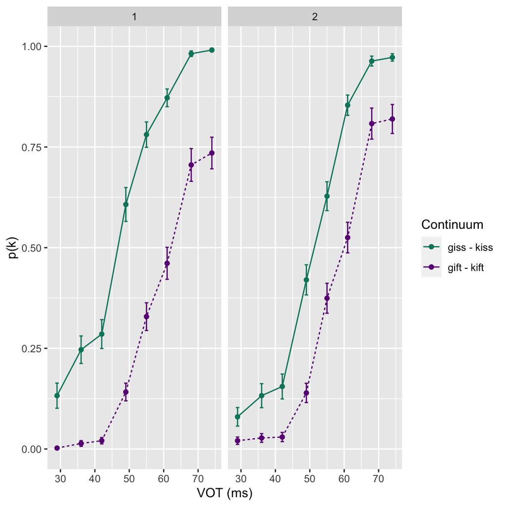

```r
# Plot.
ganong.plot <- ggplot(ganong.summary, aes(x=VOT, y=K.Mean, color=Continuum)) +
  #theme_cowplot(font_size=20) +
  geom_point() +
  facet_wrap(. ~ Session) +
  geom_line(aes(linetype=Continuum), size=0.5, show.legend = FALSE) +
  geom_errorbar(aes(ymin = K.Mean-K.SE, ymax = K.Mean+K.SE), width = 1) +
  ylim(0, 1) +
  labs(x="VOT (ms)", y = "p(k)") +
  scale_color_manual(values=c("#00846b", "#6a0084"),
                     labels = c("giss - kiss",
                                "gift - kift"))

ganong.plot
```

## Report information about the analysis